# Homework #7, Part C

Jules Ford

2023-03-08

**Problem 4**

First I’ll load in some packages:

```r
library(ggplot2) # for graphics
library(MASS) # for maximum likelihood estimation
```

Next, I’ll plot the new randomized plot:

```r
voleData <- read.table("hwk7Data.csv",header=TRUE,sep=",")
normPars <- fitdistr(voleData$Initial.plant.volume..m3.,"normal")
normPars$estimate["mean"]
```

```
## mean
## 4.84
```

```r
meanML <- normPars$estimate["mean"]
sdML <- normPars$estimate["sd"]
normPars$estimate["sd"]
```

```
##       sd
## 3.286348
```

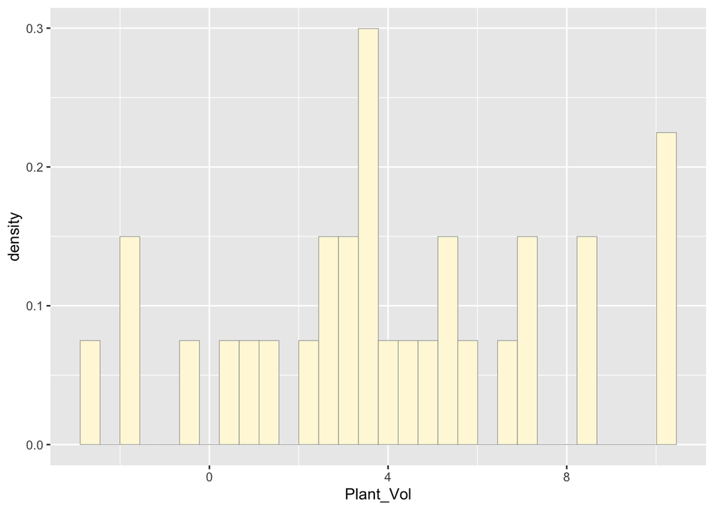

```r
simulatedData <- data.frame(Plant_Vol=rnorm(30, mean = normPars$estimate["mean"], sd = normPars$estimate["sd"]))

newGraph <- ggplot(data=simulatedData, aes(x=Plant_Vol, y=..density..)) +
  geom_histogram(color="grey60",fill="cornsilk",linewidth=0.2)
print(newGraph)
```

Here I’ll plot the graph from Part B with the real data:

```r
# This is code I pulled from Part B
voleData <- read.table("hwk7Data.csv",header=TRUE,sep=",")
p1 <- ggplot(data=voleData, aes(x=Initial.plant.volume..m3., y=..density..)) +
  geom_histogram(color="grey60",fill="cornsilk",linewidth=0.2)
normPars <- fitdistr(voleData$Initial.plant.volume..m3.,"normal")
normPars$estimate["mean"]
```

```
## mean
## 4.84
```

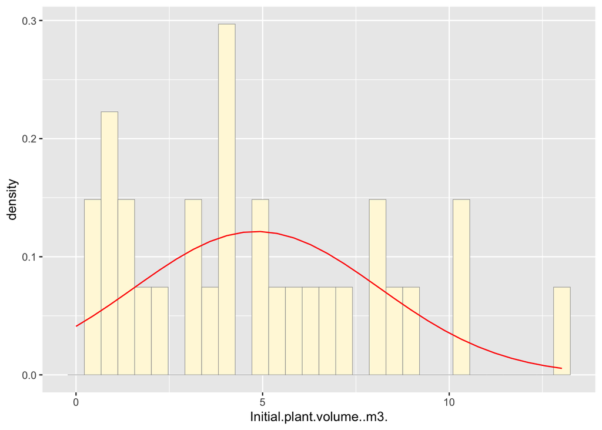

```r
meanML <- normPars$estimate["mean"]
sdML <- normPars$estimate["sd"]
xval <- seq(0,max(voleData$Initial.plant.volume..m3.),len=length(voleData$Initial.plant.volume..m3.))
stat <- stat_function(aes(x = xval, y = ..y..), fun = dnorm, colour="red", n = length(voleData$Initial.plant.volume..m3.), args = list(mean = meanML, sd = sdML))
p1 + stat
```

Question to answer: How do the two histogram profiles compare? Do you think the model is doing a good job of simulating realistic data that match your original measurements? Why or why not?

The two histograms are quite different. First, the original histogram from the data doesn’t fit the normal distribution very well (but normal distribution was the closest fitting distribution nonetheless). I think if the dataset had a larger sample size the data would be more consistent between the two graphs.

I don’t think the model does a good job of simulating realistic data, because it often generates some x values below 0. The x axis represents initial plant volumes, which is nonsensical because volume can’t be negative.